# NPCA Data analysis

Ajwal Dsouza

2024-05-23

The overall goal of this script is to measure the photosynthetic CO2 flux as $\mu mols~CO_2~m^{-2}~leaf~area~s^{-1}$ from time-series environment data measured in a sealed growth chamber. The time-series environment data consists of temperature (C) and CO2 (ppm) measured every minute.

In the growth chamber, CO2 is injected to reach a specific set-point concentration (ppm). The plants in the chambers draw down the CO2 through photosynthesis. When the CO2 concentration reaches a pre-set lower threshold, CO2 in injected back to bring the concentration to the setpoint.

To accurately calculate the plant net photosynthetic carbon assimilation (NPCA), we follow these given steps:

1. Identify the injection events and remove those datapoints
2. For the dataset that is excluded of injection events, loop through each row of the CO2 ppm readings and calculate the slope and rsq values for 30 subsequent values and save as new columns
3. Write a function to calculate photosynthetic CO2 flux (Flux) as micromol CO2/m2 leaf area/s using the slopes, chamber volume (input manually), canopy leaf area (A, input manually) and corresponding measured temperature using the equation given below:

   $$NPCA = slope \times \frac{p} {R T} \times \frac{V} {A}$$

   Where, $NPCA$ is the net photosynthetic carbon assimilation in $\mu mols~CO_2~m^{-2}~s^{-1}$, $slope$ is the change of CO2 over time in ppm/min. $p$ is the atmospheric pressure (assumed 1 atm), *R* is the ideal gas constant (0.082 $L~ atm ~K^{-1}~mol^{-1}$), and *T* is the air temperature in K. *V* is the chamber volume in L, and *A* is the total leaf area of the whole canopy in the chamber as $m^{-2}$.

This script processes a dataset to identify and remove CO2 injection events, calculates slopes and R-squared values for linear regressions on windows of 30 data points, and finally computes the photosynthetic CO2 flux based on these slopes and additional parameters like chamber volume and canopy leaf area.

# Initial setup

## Setting working directory

Set the working directory for the project. The `setwd` line sets the source file location of the R script as the working directory.

```r
setwd(dirname(getActiveDocumentContext()$path))
```

## Importing datafiles

First, set the folder that contains the raw data files as `mydir`. Next, we list all the files with .csv files in the specified “mydir” as `myfiles` and call the list.

```r
mydir="raw"
myfiles= list.files(path=mydir, pattern="*.csv", full.names=TRUE)
myfiles
```

```
## [1] "raw/2023-07-12.csv"
```

## Importing datafiles into single dataframe

The following code imports all the .csv files in the raw data folder into one single dataset, called `datamaster`.

```r
data_master <- ldply(myfiles, read.table, sep = ",", fill=T, header = F)%>%     #collectively apply "impost function for all the files in the specified directory
  as_tibble()%>%                                                                #Convert the imported data as a tibble
  na.omit()%>%
  select(V = c(V1,V2,V12, V13, V21))%>%
  #Rename  the columns while importing.
  rename(time=V1,
         temp = V2,
         light_int = V3,
         co2_read = V4,
         co2_set = V5)%>%
  slice(c(1:1440))
```

# Data Cleaning

Next, let us clean the raw data and prep it for the analysis.

## Setting the data type for each column

Setting all the columns except 1st to as numeric

```r
data_master[, 2:ncol(data_master)] <-
  lapply(data_master[,2:ncol(data_master)], as.numeric)
```

Setting first column as date-time variable

```r
data_master$time <- as_datetime(data_master$time)
```

## Identifying and removing injection events

In the raw file, there are injection events where CO2 is injected to reach the CO2 setpoint, where there is a rapid rise of CO2 concentration in a relatively short duration of time (compared to plant CO2 draw-down rate). This can create a nuisance during the calculation of photosynthetic flux.

### Define a threshold for detecting injection events

This line sets a threshold value 10 (10 ppm rise between subsequent readings) for detecting significant changes (injection events) in the `CO2` levels.

```r
threshold <- 10
```

### Identify and remove injection events

Based on the defined threshold, identify and remove the injection events to save the datafile as `cleaned_data`.

```r
cleaned_data <- data_master %>%
  mutate(injection = if_else((co2_read - lag(
    co2_read, default = first(co2_read))) > threshold, TRUE, FALSE)) %>%
  filter(injection == FALSE) %>%
  select(-injection)
```

Here,

- `mutate`: Adds a new column to the DataFrame.
- `lag(CO2, default = first(CO2))`: Shifts the `CO2` column down by one row, filling the first value with the first value of the `CO2` column to handle the edge case.
- `(CO2 - lag(CO2)) > threshold`: Calculates the difference between the current and the previous `CO2` value, then checks if this difference exceeds the threshold.
- `if_else(..., TRUE, FALSE)`: Creates a boolean column `injection` that is `TRUE` if the difference exceeds the threshold and `FALSE` otherwise.
- `filter(injection == FALSE)`: Filters out rows where `injection` is `TRUE`, keeping only rows without injection events.
- `select(-injection)`: Removes the `injection` column from the DataFrame.

## Creating a minutes column

Create a new column named `minutes` with consecutive numbers starting from zero

```r
cleaned_data$minutes <- seq(0, by = 1, length.out = nrow(cleaned_data))

# data_master$minutes <- data_master$minutes*10
# data_master$hours <- data_master$minutes/60
```

If the dataset with readings every minute is to be reduced to retain reading for longer intervals (e.g., 10 mins), run the following code by specifying the desired time interval in the command `breaks`.

```r
# # #Reducing the dataset by reducing sampling interval
# groups <- cut(as.POSIXct(data_master$time), breaks="10 min")
# library(plyr)
# data_master <- ddply(data_master, "groups", tail, 1)[, -1]
```

## Visualizing the raw CO2 readings

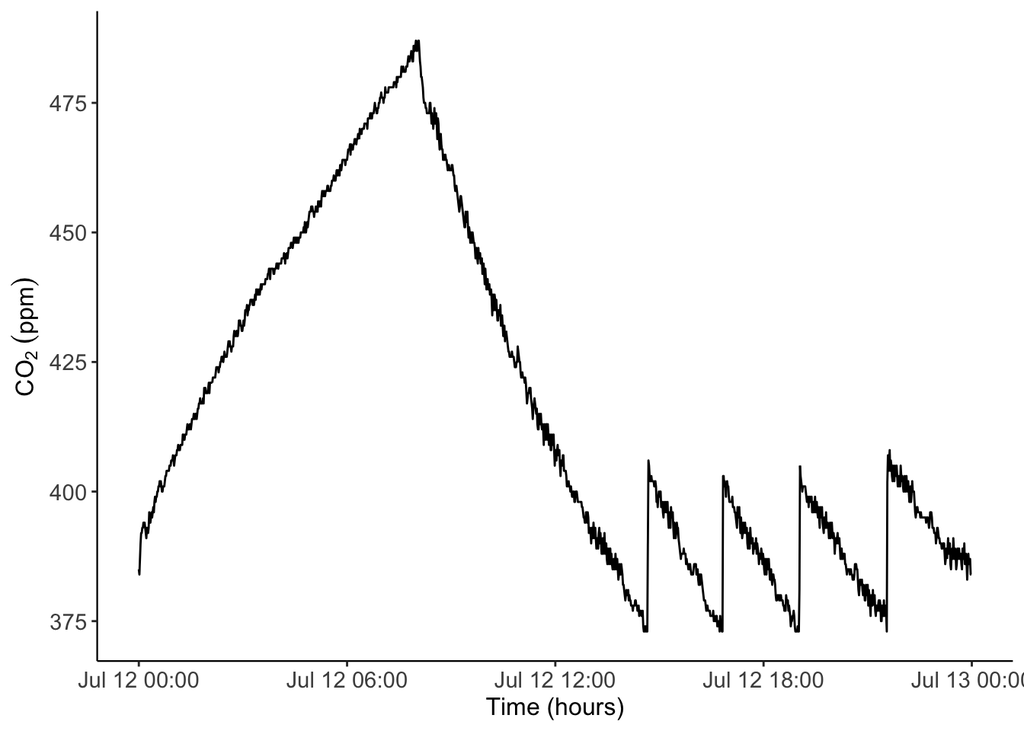

```r
p <-
  ggplot(aes(x=time, y=co2_read), data = data_master) +
  geom_line()+
  labs(x="Time (hours)", y=expression(CO[2]~(ppm)), color="10:1")+
  theme_classic()+
  theme(axis.text = element_text(size = 11),
        axis.title = element_text(size = 12),
        axis.line = element_line(size = 0.4))+
  theme(legend.position = c(0.8, 0.75),
        legend.direction = "vertical",
        legend.title = element_text(size = 12),
        legend.text = element_text(size = 10))
p
```

# Calculating the net photosynthetic assimilation rate

We have to calculate the rate of change of CO2 over time in ppm/min, as the moving slopes of the linear fits through least squares method for 30 consecutive readings.

## Calculating the rate of change of CO2 over time as slope

### Function to calculate slope and R-squared for consecutive points

First, we create a function that calculates the slope and R-squared for consecutive points.

```r
calc_slope_rsq <- function(x, y) {
  model <- lm(y ~ x)
  slope <- coef(model)[2]
  rsq <- summary(model)$r.squared
  return(list(slope = slope, rsq = rsq))
}
```

This function performs a linear regression on a set of points:

- `lm(y ~ x)`: Fits a linear model.
- `coef(model)[2]`: Extracts the slope (coefficient of `x`).
- `summary(model)$r.squared`: Extracts the R-squared value, indicating how well the model fits the data.

### Apply the function to calculate slope and R-squared for each window of 30 consecutive points

```r
cleaned_data <- cleaned_data %>%
  mutate(slope = NA, rsq = NA)

for (i in 1:(nrow(cleaned_data) - 30)) {
  result <- calc_slope_rsq(cleaned_data$minutes[i:(i + 30)], cleaned_data$co2_read[i:(i + 30)])
  cleaned_data$slope[i + 2] <- result$slope  # Center the slope value
  cleaned_data$rsq[i + 2] <- result$rsq      # Center the rsq value
}
```

```r
cleaned_data <- cleaned_data %>%
  filter(!is.na(slope) & !is.na(rsq))
```

## Filtering low-fit datapoints

For the slopes calculated, there would be points with low rsq, especially in places between an injection event. These are nuisance artefacts that must be removed.

We will set our lower rsq threshold as `filter_rsq`

```r
filter_rsq <- 0.5
```

Filter the data to eliminate the readings with rsq lower than the set threshold

```r
cleaned_data <-
  cleaned_data%>%
  subset(rsq >= filter_rsq)
```

## Define the function to calculate photosynthetic CO2 flux

Next, we create a function `calc_flux` to calculate the net photosynthetic carbon assimilation (NPCA) as $\mu mols~CO_2~m^{-2}~s^{-1}$ using the ideal gas law.

```r
calc_flux <- function(slope, T, V, A) {
  p <- 1  # atmospheric pressure in atm
  R <- 0.082  # ideal gas constant in L atm K−1 mol−1
  T_k <- T + 273.15  # convert temperature from Celsius to Kelvin

  flux <- -slope * (p / (R * T_k)) * V / A
  return(flux)
}
```

Here,

- `p`: Atmospheric pressure (1 atm).
- `R`: Ideal gas constant.
- `T_k`: Converts temperature from Celsius to Kelvin.
- `flux`: Calculates the photosynthetic CO2 flux using the given formula.
- `V`: volume of the chamber (L)
- `A`: Total leaf area of the plant canopy ($m^2$)

### Manually input the chamber volume (V) in liters and canopy leaf area (A) in $m^2$

Set the volume of the chamber and the area of the canopy, which are used in the flux calculation.

```r
V <- 100  #  value in liters
A <- 1  #  value in m^2
```

## Apply the flux calculation to the dataset

Add a new column `flux` to `cleaned_data` by applying the `calc_flux` function to each row.

```r
cleaned_data <- cleaned_data %>%
  mutate(flux = calc_flux(slope, temp, V, A))
```

### Visualize the NPCA derived from the processed dataset

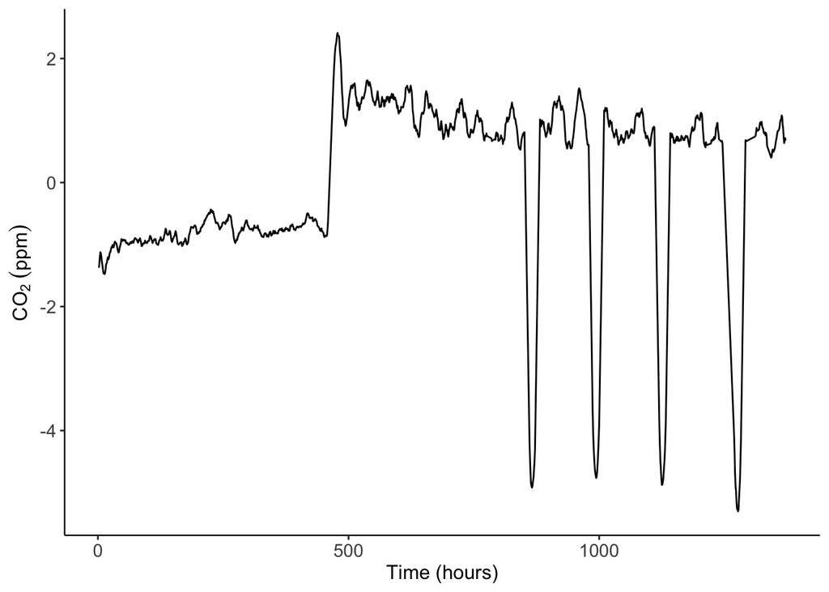

```r
ggplot(aes(x=minutes, y=flux), data = cleaned_data) +
  geom_line()+
  labs(x="Time (hours)", y=expression(CO[2]~(ppm)))+
  theme_classic()+
  theme(axis.text = element_text(size = 11),
        axis.title = element_text(size = 12),
        axis.line = element_line(size = 0.4))+
  theme(legend.position = c(0.8, 0.75),
        legend.direction = "vertical",
        legend.title = element_text(size = 12),
        legend.text = element_text(size = 10))
```

We can use the plot to visually inspect for any anomalies or noise in the data. As we can see in the plot, there are four drops in NPCA, which if parsed through in the data, we find are due to the injection events. We can eliminate these anomalies by manually filtering out these anomalous data-points as such:

```r
npca_data <-
  cleaned_data%>%
  subset(flux > -2)
```

I selected the flux (or NPCA) cutoff -2 based on visual inspection, and created a final data frame called `npca_data`.

Lets plot the final data:

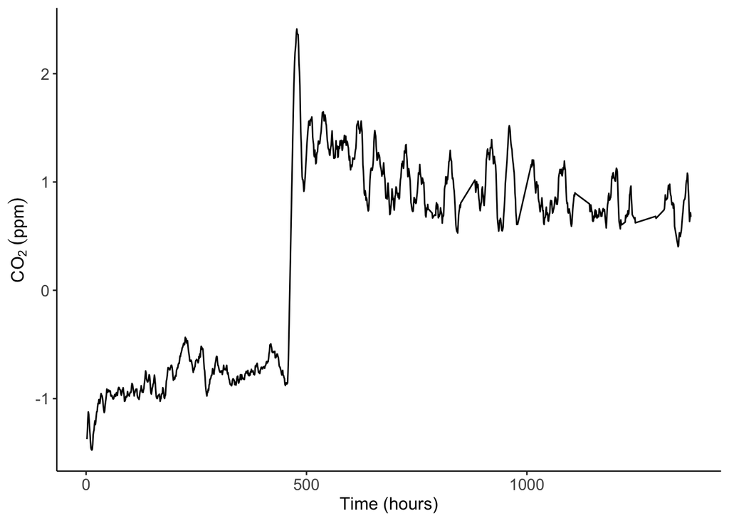

```r
ggplot(aes(x=minutes, y=flux), data = npca_data) +
  geom_line()+
  labs(x="Time (hours)", y=expression(CO[2]~(ppm)))+
  theme_classic()+
  theme(axis.text = element_text(size = 11),
        axis.title = element_text(size = 12),
        axis.line = element_line(size = 0.4))+
  theme(legend.position = c(0.8, 0.75),
        legend.direction = "vertical",
        legend.title = element_text(size = 12),
        legend.text = element_text(size = 10))
```

THIS LOOKS GOOD!

# Additional Analyses

## Outlier detection and removal using Rosner’s test

Perform a Rosner’s test using the function `rosnerTest` from the `EnvStat` package. Set ‘k’ as the maximum number of outliers to test for. Adjust as necessary. Run the Rosner’s test.

> NOTE: The Rosner’s test is only appropriate when calculating only day-NPCA, not diurnal NPCA, which will inherently differ substantially from the day.

```r
k <- 10  # example value, adjust based on your needs
rosner_test <- EnvStats::rosnerTest(npca_data$flux, k = k)
```

### View the results of the Rosner’s test

```r
print(rosner_test)
```

```
##
## Results of Outlier Test
## -------------------------
##
## Test Method:                     Rosner's Test for Outliers
##
## Hypothesized Distribution:       Normal
##
## Data:                            npca_data$flux
##
## Sample Size:                     1179
##
## Test Statistics:                 R.1  = 2.252247
##                                  R.2  = 2.218765
##                                  R.3  = 2.221776
##                                  R.4  = 2.218042
##                                  R.5  = 2.218591
##                                  R.6  = 2.148024
##                                  R.7  = 2.113226
##                                  R.8  = 2.101047
##                                  R.9  = 2.061758
##                                  R.10 = 1.975433
##
## Test Statistic Parameter:        k = 10
##
## Alternative Hypothesis:          Up to 10 observations are not
##                                  from the same Distribution.
##
## Type I Error:                    5%
##
## Number of Outliers Detected:     0
##
##    i    Mean.i      SD.i    Value Obs.Num    R.i+1 lambda.i+1 Outlier
## 1  0 0.3000850 0.9380353 2.412772     468 2.252247   4.080278   FALSE
## 2  1 0.2982915 0.9364093 2.375964     467 2.218765   4.080072   FALSE
## 3  2 0.2965263 0.9348445 2.373541     469 2.221776   4.079866   FALSE
## 4  3 0.2947601 0.9332756 2.364805     470 2.218042   4.079659   FALSE
## 5  4 0.2929984 0.9317147 2.360092     471 2.218591   4.079452   FALSE
## 6  5 0.2912376 0.9301540 2.289230     466 2.148024   4.079245   FALSE
## 7  6 0.2895343 0.9287172 2.252124     472 2.113226   4.079038   FALSE
## 8  7 0.2878598 0.9273404 2.236245     465 2.101047   4.078831   FALSE
## 9  8 0.2861959 0.9259848 2.195352     464 2.061758   4.078623   FALSE
## 10 9 0.2845641 0.9246949 2.111237     463 1.975433   4.078416   FALSE
```

### Extract and remove the outlier indices

If there are any outliers present, we can extract and remove them from the data. This first code extracts the outliers as identified in the Rosner’s test.

```r
outlier_indices <-
rosner_test$all.stats[rosner_test$all.stats$Outlier, "Index"]
```